# STAT 420: Final Project

Chenhan Xu (chenhan2)

Friday, May 3

### Abstract

This report will try to fit a proper linear regression model to predict the `Disease.Severity` in the `disease` dataset using other variables. We will first check the **multicollinearity** of the dataset and try to reduce the predictors. Then we will fit the full **additive** linear models and try to interpret and diagnose them with different methods. **Cook’s Distance** will be used to remove the influencial unusual observation. As the model do not fit the data well, **response transformation** is used to find a better one. For each family of models, we use **Bayesian Information Criterion (BIC)** to do the variable selection. BIC is preferred here instead of AIC because with large sample data size, BIC tends to find a smaller model that can be more interpretable. Test of model assumption will be given to each of the models. A comparison is given to different models to find a best one. We will also use **Exhuasitive Search** to identify if the search miss the best model. Finally, this report will arrive at a proper model for the dataset.

### Setup of the project

Import the `disease` dataset and the packages that contain the necessary functions for this project.

```r
library(faraway)
library(lmtest)
library(MASS)
library(leaps)
```

```r
disease = read.csv("Disease Data.csv")
```

Define some of the functions that we may need for convenience.

```r
fitted_vs_resid = function(model) {
  plot(fitted(model), resid(model),
       col = "grey", pch = 20,
       xlab = "Fitted Value",
       ylab = "Residual",
       main = "Fitted Value versus Residual")
  abline(h = 0, lwd = 3, col = "dodgerblue")
}
qqplot = function(model) {
  qqnorm(resid(model), col = "grey", lwd = 3)
  qqline(resid(model), col = "dodgerblue", cex = 1.5, pch = 20)
}
calc_loocv_rmse = function(model) {
  sqrt(mean((resid(model) / (1 - hatvalues(model))) ^ 2))
}
```

### Summary Statistics and Data Visualization

First, look at the variales of the data frame.

```r
str(disease)
```

```
## 'data.frame':    290 obs. of  22 variables:
##  $ X               : int  1 2 3 4 5 6 7 8 9 10 ...
##  $ Disease.Severity: num  1.878 1.784 0.949 1.82 2.04 ...
##  $ PCDH12          : num  0.477 1.554 0.961 1.088 1.408 ...
##  $ DLG5            : num  0.844 1.259 3.701 0.746 0.976 ...
##  $ BC038559        : num  1.081 1.254 0.746 0.939 1.259 ...
##  $ SHISA5          : num  1.562 1.178 1.367 0.993 0.611 ...
##  $ AF161342        : num  0.423 0.723 0.54 1.415 0.857 ...
##  $ CARKD           : num  0.842 0.88 0.97 1.064 1.264 ...
##  $ F2R             : num  0.471 1.134 1.217 1.312 0.524 ...
##  $ PHKG1           : num  2.521 0.875 1.355 0.898 1.528 ...
##  $ CDCP1           : num  1.139 2.596 0.854 1.474 0.789 ...
##  $ PLEKHM1         : num  0.378 1.275 1.141 0.877 1.542 ...
##  $ SMC2            : num  0.552 0.895 1.06 0.859 0.842 ...
##  $ PSMB6           : num  0.48 1.066 0.967 1.128 0.869 ...
##  $ BX440400        : num  1.272 0.841 1.01 0.933 1.532 ...
##  $ A_24_P936373    : num  1.7 0.813 0.379 0.855 1.207 ...
##  $ PPAN            : num  1.101 0.862 1.416 0.674 0.843 ...
##  $ BC007917        : num  1.845 1.24 1.902 1.161 0.753 ...
##  $ C14orf143       : num  2.192 1.672 2.585 1.215 0.669 ...
##  $ LOC440104       : num  0.26 1.04 2.33 1.36 1.12 ...
##  $ THC2578957      : num  0.713 1.205 1.4 1.238 0.568 ...
##  $ ANKIB1          : num  0.681 0.98 3.093 1.472 1.059 ...
```

`X` variable is the index of observations. In this case, the data of different patients is independent with the index, so remove `X` from the data frame.

Besides, there is no factor variable in the dataset, so the model will not have dummy variables.

```r
disease = subset(disease, select = - X)
```

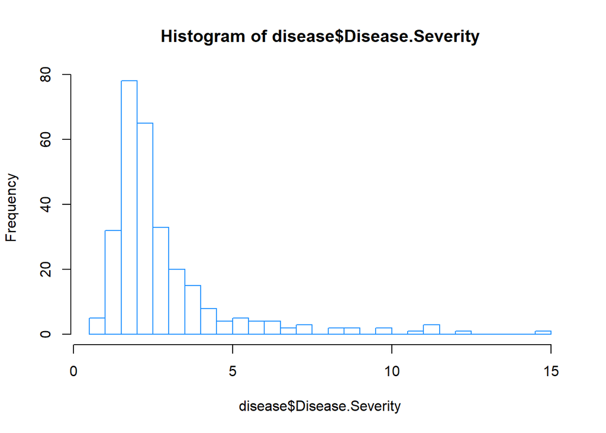

```r
hist(disease$Disease.Severity, breaks = 50,
     border = "dodgerblue")
```

The histogram shows the distribution of `Disease.Severity` is right skewed.

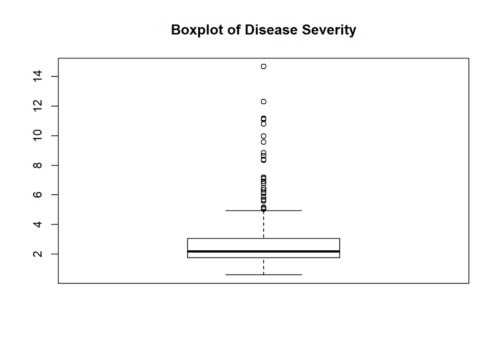

```r
boxplot(disease$Disease.Severity, main = "Boxplot of Disease Severity")
```

The boxplot shows that the median of `Disease.Severity` is slightly over 2, but there are a lot of outliers in the dataset.

The table below shows some important statistics of `Disease.Severity`.

```r
data_analysis = data.frame(
  "Measure" = c("Mean", "Median", "Variance", "Standard Deviation", "Max", "Min"),
  "Result" = c(mean(disease$Disease.Severity), median(disease$Disease.Severity), var(disease$Disease.Severity), sd(disease$Disease.Severity), max(disease$Disease.Severity), min(disease$Disease.Severity)))
knitr::kable(data_analysis)
```

| Measure | Result |
| --- | --- |
| Mean | 2.8468 |
| Median | 2.1938 |
| Variance | 4.0965 |
| Standard Deviation | 2.0240 |
| Max | 14.6548 |
| Min | 0.6051 |

Before starting fitting the model, check if there is collinearity in between variables to see if we can reduce some variables.

Test the mulitcollinearity using **variance inflation factor (VIF)**.

```r
vif(disease)[which(vif(disease) > 5)]
```

```
##     F2R PLEKHM1
##   5.929   5.917
```

Notice that predictors `F2R` and `PLEKHM1` have **vif** greater than 5. Therefore, look at variable added plots and partial correlation coefficients for these two predictors.

First, focus on `F2R`.

```r
fit_full_without_F2R = lm(Disease.Severity ~ . - F2R, data = disease)
fit_F2R = lm(F2R ~ . - Disease.Severity, data = disease)
```

```r
cor(resid(fit_full_without_F2R), resid(fit_F2R))
```

```
## [1] 0.2017
```

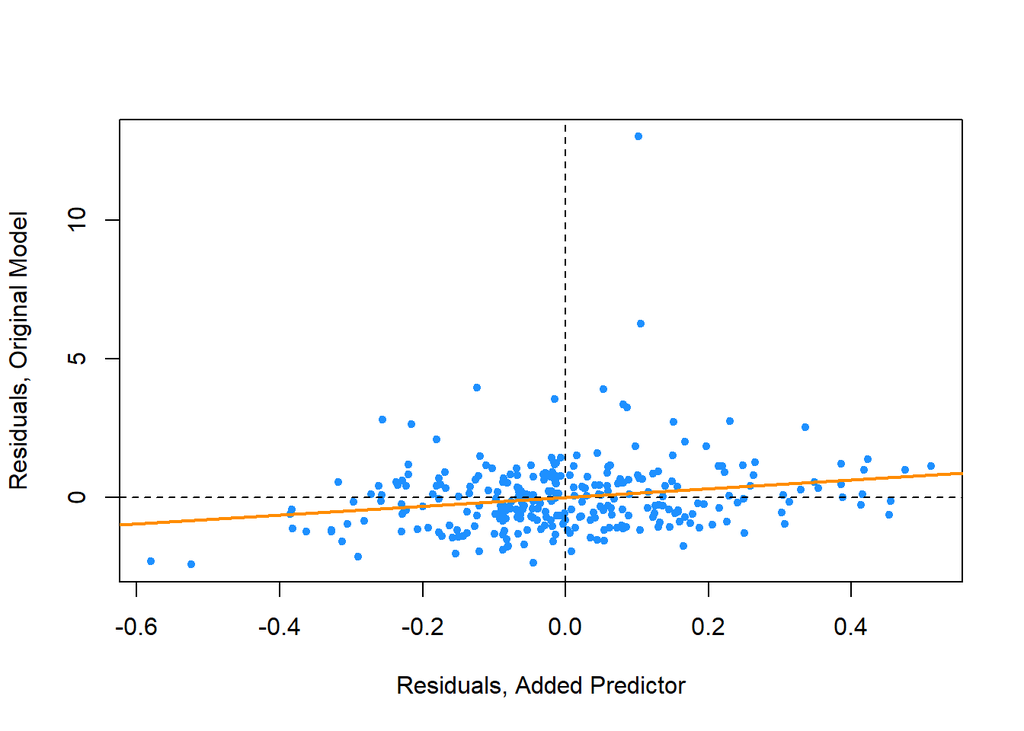

```r
plot(resid(fit_full_without_F2R) ~ resid(fit_F2R),
     col = "dodgerblue", pch = 20,
     xlab = "Residuals, Added Predictor",
     ylab = "Residuals, Original Model")
abline(h = 0, lty = 2)
abline(v = 0, lty = 2)
abline(lm(resid(fit_full_without_F2R) ~ resid(fit_F2R)),
       col = "darkorange", lwd = 2)
```

Next, look at `PLEKHM1`.

```r
fit_full_without_PLEKHM1 = lm(Disease.Severity ~ . - PLEKHM1, data = disease)
fit_PLEKHM1 = lm(PLEKHM1 ~ . - Disease.Severity, data = disease)
```

```r
cor(resid(fit_full_without_PLEKHM1), resid(fit_PLEKHM1))
```

```
## [1] 0.6243
```

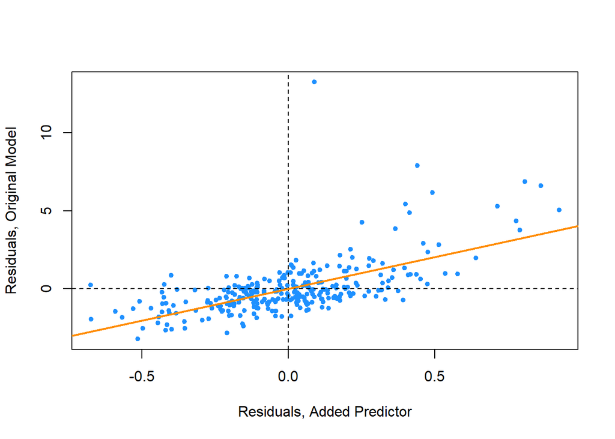

```r
plot(resid(fit_full_without_PLEKHM1) ~ resid(fit_PLEKHM1),
     col = "dodgerblue", pch = 20,
     xlab = "Residuals, Added Predictor",
     ylab = "Residuals, Original Model")
abline(h = 0, lty = 2)
abline(v = 0, lty = 2)
abline(lm(resid(fit_full_without_PLEKHM1) ~ resid(fit_PLEKHM1)),
       col = "darkorange", lwd = 2)
```

The partial correlation coefficients of both predictors are unignorable. The variable added plots also show that the variations of `F2R` and `PLEKHM1` have correlation with other predictors. This means that their variations are unexplained by other predictors. Hence, we prefer to keep these two predictors in the model.

### Full Model

Try to fit the full additive model.

```r
fit_full_add = lm(Disease.Severity ~ ., data = disease)
```

```r
summary(fit_full_add)
```

```
##
## Call:
## lm(formula = Disease.Severity ~ ., data = disease)
##
## Residuals:
##    Min     1Q Median     3Q    Max
## -2.307 -0.784 -0.142  0.599 12.865
##
## Coefficients:
##              Estimate Std. Error t value Pr(>|t|)
## (Intercept)  -3.40326    0.88358   -3.85  0.00015 ***
## PCDH12       -0.11278    0.07623   -1.48  0.14021
## DLG5         -0.74302    0.22719   -3.27  0.00121 **
## BC038559     -0.29818    0.36725   -0.81  0.41755
## SHISA5        0.29250    0.32387    0.90  0.36727
## AF161342      0.56846    0.14971    3.80  0.00018 ***
## CARKD         0.17338    0.09795    1.77  0.07784 .
## F2R           1.58782    0.47023    3.38  0.00084 ***
## PHKG1         0.50079    0.23772    2.11  0.03608 *
## CDCP1         0.12425    0.18041    0.69  0.49161
## PLEKHM1       4.06100    0.30984   13.11  < 2e-16 ***
## SMC2          0.08645    0.04138    2.09  0.03766 *
## PSMB6        -0.87261    0.35442   -2.46  0.01444 *
## BX440400     -0.00574    0.26574   -0.02  0.98279
## A_24_P936373  0.52884    0.20653    2.56  0.01100 *
## PPAN          0.32410    0.26562    1.22  0.22347
## BC007917     -0.28250    0.30706   -0.92  0.35838
## C14orf143     0.19825    0.11201    1.77  0.07786 .
## LOC440104    -0.86823    0.30943   -2.81  0.00538 **
## THC2578957    0.43789    0.32130    1.36  0.17406
## ANKIB1        0.08339    0.34285    0.24  0.80801
## ---
## Signif. codes:  0 '***' 0.001 '**' 0.01 '*' 0.05 '.' 0.1 ' ' 1
##
## Residual standard error: 1.39 on 269 degrees of freedom
## Multiple R-squared:  0.561,  Adjusted R-squared:  0.528
## F-statistic: 17.2 on 20 and 269 DF,  p-value: <2e-16
```

The full additive model contains 21 coefficients. The F-test shows that the model is significant. However, the single variable t-tests show that many of the predictors in the full additive model are insignificant.

Next, check if the model violate some of the assumptions.

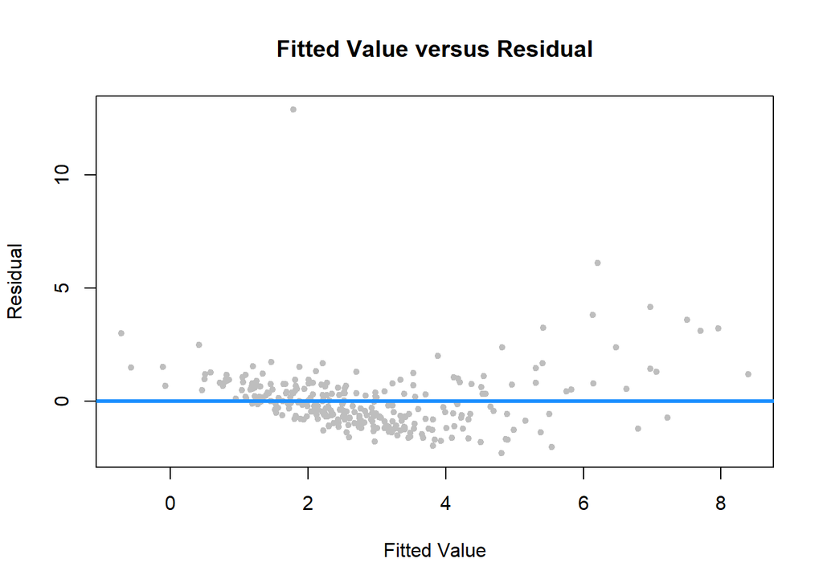

```r
fitted_vs_resid(fit_full_add)
```

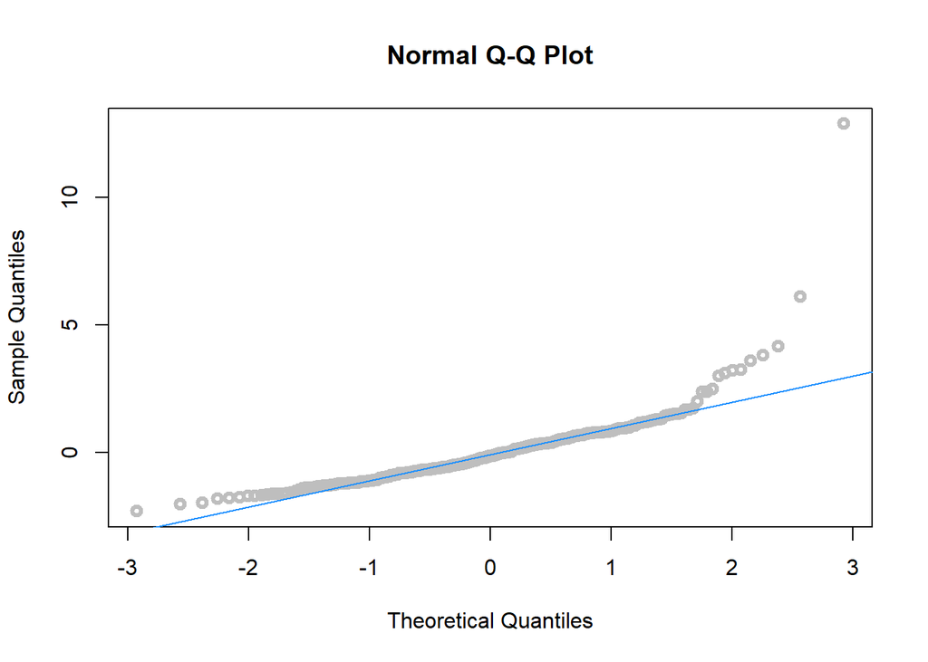

```r
qqplot(fit_full_add)
```

Notice that there are some unusual data points in the plot, so use the **Cook’s Distance** to identify and remove them.

```r
n = nrow(disease)
p = length(coef(fit_full_add))
```

```r
cook_full_add = cooks.distance(fit_full_add)
outlier = which(cook_full_add > 4 / n)
```

Because all of our model is based on the full linear model, drop the unusual influential observations based on the full linear model.

```r
disease = disease[-outlier,]
```

```r
fit_full_add = lm(Disease.Severity ~ ., data = disease)
```

Now, removed the unusual observations and look back intto the two plots.

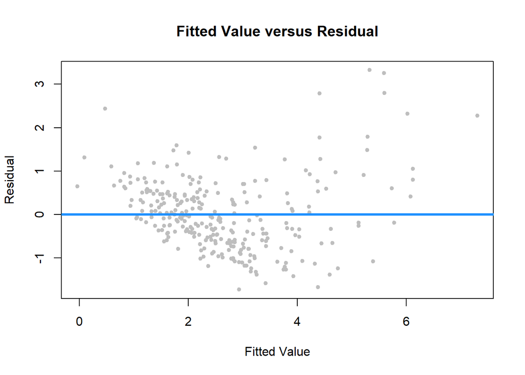

```r
fitted_vs_resid(fit_full_add)
```

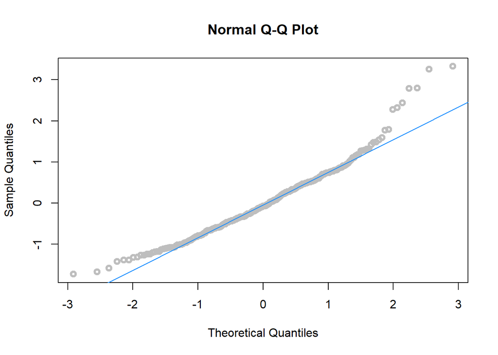

```r
qqplot(fit_full_add)
```

Through the plots, it is clearly noticed that the **Linear Assumption**, **Constant Variance Assumption** and **Normality Assumptions** are all violated. In this way, this model is terrible.

Use **BIC** to try to find a better smaller additive model.

```r
fit_bic_add = step(fit_full_add, direction = "backward", trace = 0, k = log(n))
```

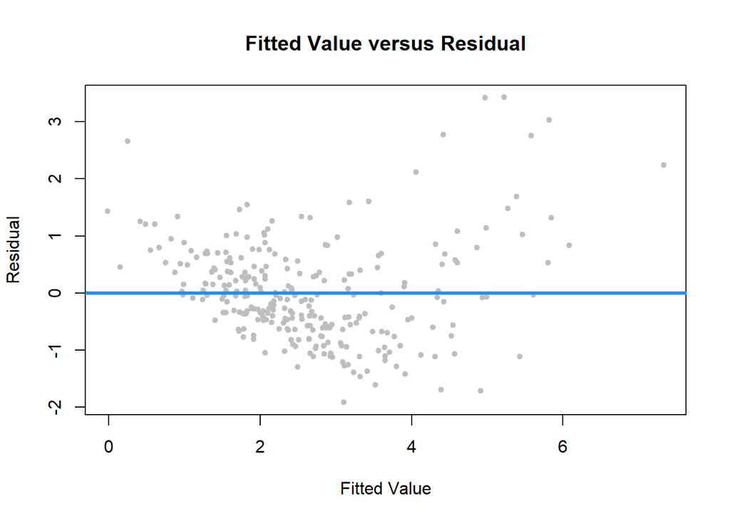

```r
fitted_vs_resid(fit_bic_add)
```

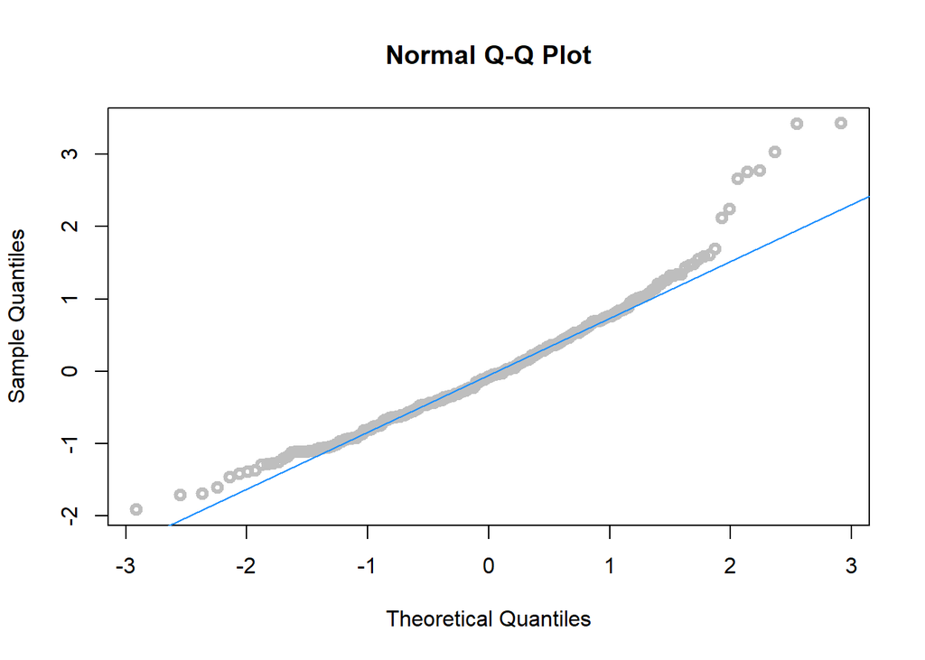

```r
qqplot(fit_bic_add)
```

However, the plots tells that the smaller additive model is again terrible. This matches our expectation since we know that simply removing predictors may not help dealing with the **linear**, **constant variance** and **normality** assumptions.

In the next few sections, we will perform response transformation to find a better model.

### Log mode

The Fitted Value vs Residual plot shown above suggests that a **log-transformation** on response may be helpful.

```r
fit_full_log_add = lm(log(Disease.Severity) ~ ., data = disease)
```

Fit a full log model and then use **BIC** to find a proper smaller model.

```r
fit_bic_log_add = step(fit_full_log_add, direction = "backward", k = log(n), trace = 0)
```

```r
summary(fit_bic_log_add)
```

```
##
## Call:
## lm(formula = log(Disease.Severity) ~ PCDH12 + DLG5 + SHISA5 +
##     AF161342 + CARKD + F2R + PHKG1 + PLEKHM1 + PPAN + C14orf143,
##     data = disease)
##
## Residuals:
##     Min      1Q  Median      3Q     Max
## -0.7948 -0.1653 -0.0022  0.1708  0.8570
##
## Coefficients:
##             Estimate Std. Error t value Pr(>|t|)
## (Intercept)  -0.9483     0.1391   -6.82  6.2e-11 ***
## PCDH12       -0.4198     0.0521   -8.06  2.6e-14 ***
## DLG5         -0.4118     0.0403  -10.23  < 2e-16 ***
## SHISA5        0.2001     0.0566    3.54  0.00048 ***
## AF161342      0.2018     0.0293    6.88  4.2e-11 ***
## CARKD         0.0895     0.0185    4.85  2.1e-06 ***
## F2R           0.5551     0.0643    8.63  5.5e-16 ***
## PHKG1         0.1620     0.0435    3.72  0.00024 ***
## PLEKHM1       1.0977     0.0579   18.95  < 2e-16 ***
## PPAN          0.1297     0.0448    2.89  0.00414 **
## C14orf143     0.0907     0.0209    4.33  2.1e-05 ***
## ---
## Signif. codes:  0 '***' 0.001 '**' 0.01 '*' 0.05 '.' 0.1 ' ' 1
##
## Residual standard error: 0.261 on 268 degrees of freedom
## Multiple R-squared:  0.694,  Adjusted R-squared:  0.682
## F-statistic: 60.7 on 10 and 268 DF,  p-value: <2e-16
```

The backward search suggests a model with 10 predictors as above. Single variable t-tests show that all the predictors are significant. The F-test shows that the model is significant.

Now, look at the model assumptions.

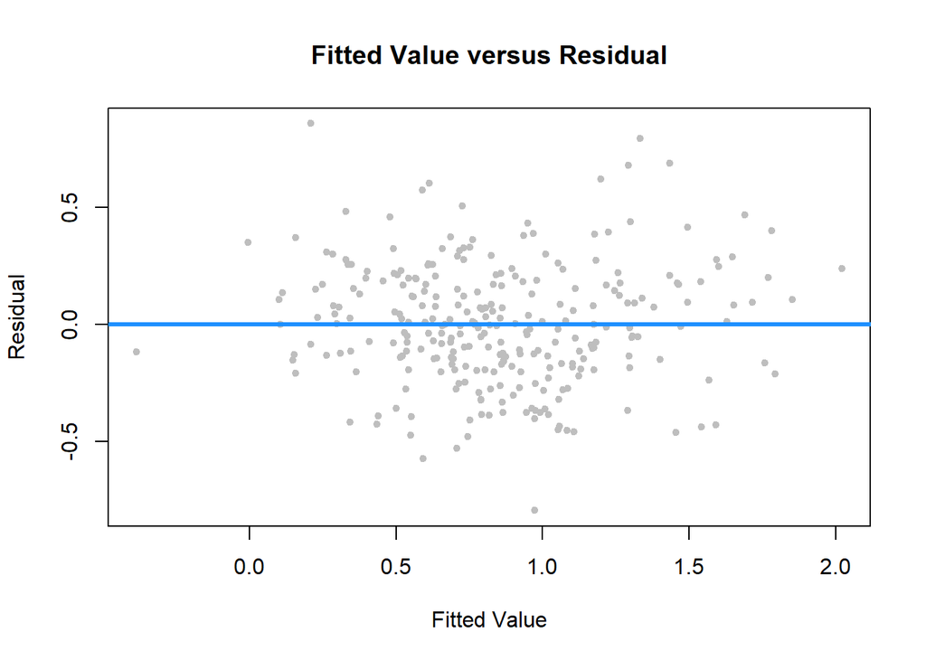

```r
fitted_vs_resid(fit_bic_log_add)
```

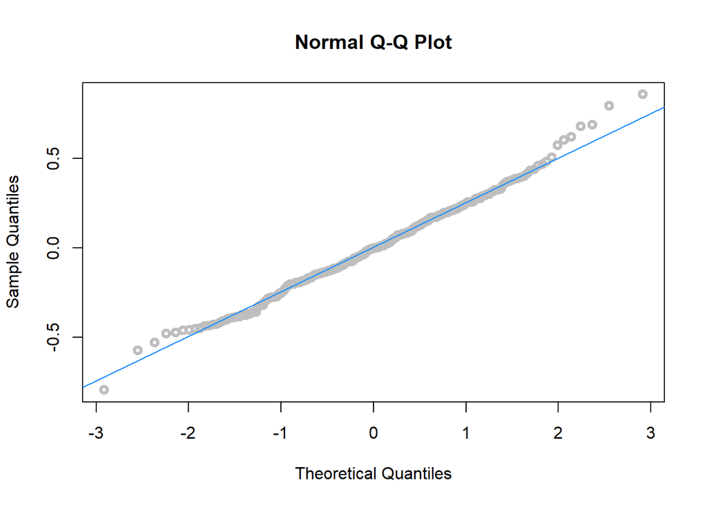

```r
qqplot(fit_bic_log_add)
```

```r
bptest(fit_bic_log_add)
```

```
##
##  studentized Breusch-Pagan test
##
## data:  fit_bic_log_add
## BP = 8.7, df = 10, p-value = 0.6
```

```r
shapiro.test(resid(fit_bic_log_add))
```

```
##
##  Shapiro-Wilk normality test
##
## data:  resid(fit_bic_log_add)
## W = 0.99, p-value = 0.2
```

The Fitted Value vs Residual plot and Q-Q plot look good. Furthermore, the **Breusch-Pagan Test** and **Shapiro-Wilk Test** both have a large p-value. Therefore, the model assumptions are not violated. This model is a good one.

In the following section, we will use **Boxcox Method** to find if there is a better response transformation.

### Boxcox model

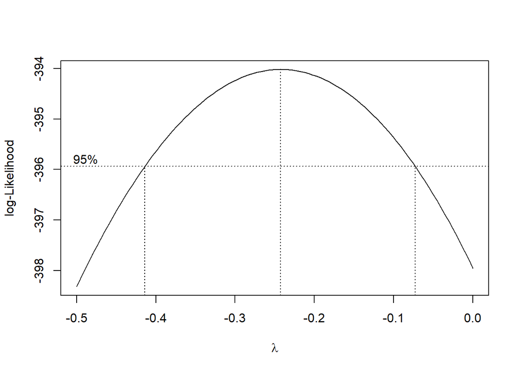

```r
boxcox(fit_full_add, plotit = TRUE, lambda = seq(-0.5, 0, by = 0.05))
```

The Boxcox plot suggests that $\lambda \in [-0.4,-0.1]$ can be a good $\lambda$ for transformation. Choose $\lambda = -0.25$ as it has relative high log-Likelihood.

Therefore, the transformation of the response is $y^{-0.25} - 1 \over -0.25$.

Fit a linear model based on this response transformation and use **BIC** to find a proper smaller model.

```r
fit_boxcox = lm(((Disease.Severity^(-0.25) - 1) / (-0.25)) ~ ., data = disease)
```

```r
fit_bic_boxcox = step(fit_boxcox, direction = "backward", trace = 0, k = log(n))
```

Summary the new model.

```r
summary(fit_bic_boxcox)
```

```
##
## Call:
## lm(formula = ((Disease.Severity^(-0.25) - 1)/(-0.25)) ~ PCDH12 +
##     DLG5 + SHISA5 + AF161342 + CARKD + F2R + PHKG1 + PLEKHM1 +
##     PPAN + C14orf143, data = disease)
##
## Residuals:
##     Min      1Q  Median      3Q     Max
## -0.6537 -0.1273  0.0016  0.1291  0.6721
##
## Coefficients:
##             Estimate Std. Error t value Pr(>|t|)
## (Intercept)  -0.6806     0.1101   -6.18  2.3e-09 ***
## PCDH12       -0.3366     0.0412   -8.16  1.3e-14 ***
## DLG5         -0.3489     0.0318  -10.95  < 2e-16 ***
## SHISA5        0.1729     0.0448    3.86  0.00014 ***
## AF161342      0.1639     0.0232    7.06  1.4e-11 ***
## CARKD         0.0673     0.0146    4.60  6.4e-06 ***
## F2R           0.4634     0.0509    9.11  < 2e-16 ***
## PHKG1         0.1350     0.0345    3.92  0.00011 ***
## PLEKHM1       0.8482     0.0458   18.51  < 2e-16 ***
## PPAN          0.1064     0.0355    3.00  0.00296 **
## C14orf143     0.0703     0.0166    4.24  3.1e-05 ***
## ---
## Signif. codes:  0 '***' 0.001 '**' 0.01 '*' 0.05 '.' 0.1 ' ' 1
##
## Residual standard error: 0.206 on 268 degrees of freedom
## Multiple R-squared:  0.692,  Adjusted R-squared:  0.681
## F-statistic: 60.3 on 10 and 268 DF,  p-value: <2e-16
```

The new model has 10 predictors all of which are significant in the model. The $R^2$ is 0.692 in the model. The statistics of the model look pretty good.

Then do the test on the model assumptions.

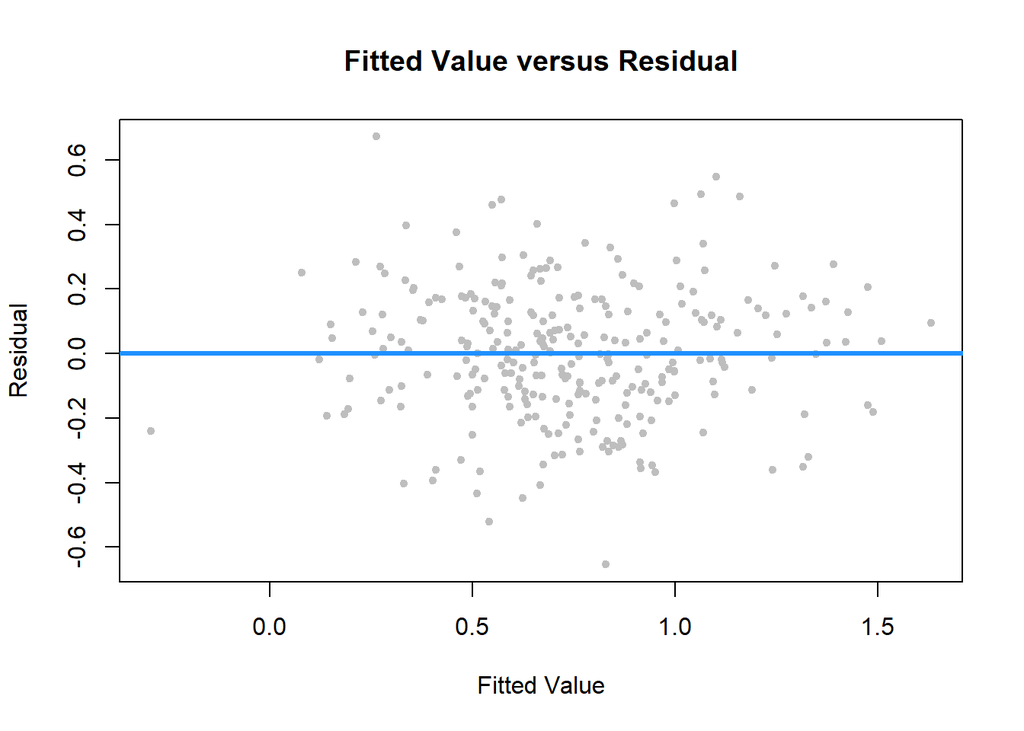

```r
fitted_vs_resid(fit_bic_boxcox)
```

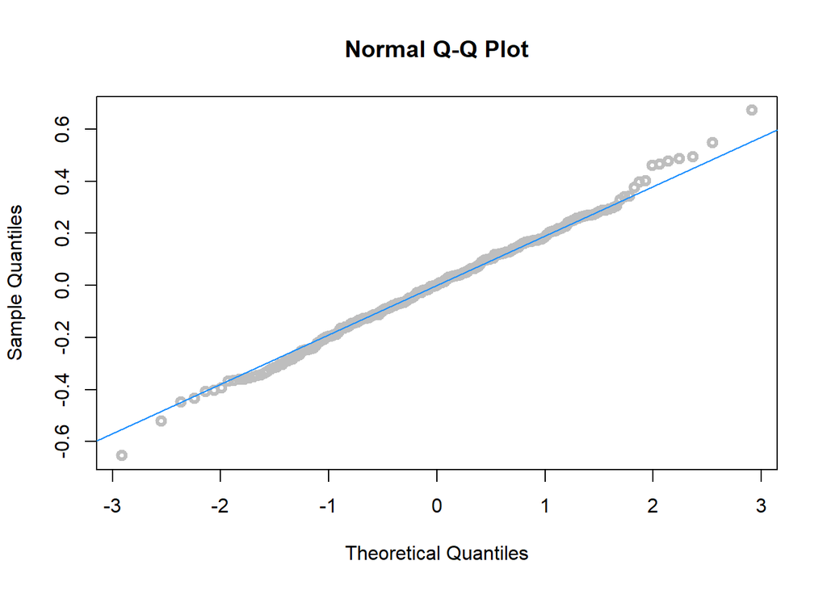

```r
qqplot(fit_bic_boxcox)
```

```r
bptest(fit_bic_boxcox)
```

```
##
##  studentized Breusch-Pagan test
##
## data:  fit_bic_boxcox
## BP = 7.8, df = 10, p-value = 0.6
```

```r
shapiro.test(resid(fit_bic_boxcox))
```

```
##
##  Shapiro-Wilk normality test
##
## data:  resid(fit_bic_boxcox)
## W = 1, p-value = 0.9
```

The Fitted Value vs Residual plot looks good, the **linear assumption** and **constant variance assumption** are not violated. The Q-Q plot also looks good, the data points fall along the normal line. **Normality assumption** is also not violated.

Furthermore, the Breusch-Pagan test and Shapiro-Wilk test both have large p-value. None of the assumptions is violated.

### Model Comparison

The **Log** model and **Boxcox** model both looks good. Do some comparison to choose a better one.

```r
all.equal(rownames(coef(fit_bic_log_add)), rownames(coef(fit_bic_boxcox)))
```

```
## [1] TRUE
```

The predictors in both model are exactly the same.

```r
summary(fit_bic_log_add)$r.squared
```

```
## [1] 0.6938
```

```r
summary(fit_bic_boxcox)$r.squared
```

```
## [1] 0.6922
```

**Log** model has a comparatively larger $R^2$ value, but the different is insignificant between the models. Therefore, Look at other statistics.

The **Boxcox** model have larger p-values in both **Breusch-Pagan test** and **Shaprio-Wilk test**. In this case, the **Boxcox** model may be slightly better.

Do the cross validation using $RMSE_{LOOCV}$.

```r
calc_loocv_rmse(fit_bic_log_add)
```

```
## [1] 0.2672
```

```r
calc_loocv_rmse(fit_bic_boxcox)
```

```
## [1] 0.2114
```

**Boxcox** model also has a smaller $RMSE_{LOOCV}$. Hence, the **Boxcox** model is preferred.

This is within expection. The **Log** transformation is actually part of **Boxcox** method. When $\lambda$ of **Boxcox** equals to $0$, the *Boxcox* transformation goes into a **log** form. In the previous **Boxcox** plot, we notice that $0$ is not in 95% interval, so **log** may not be a best transformation.

### Exhaustive Search

Because the **backward step search** may miss the best model due to its algorithm, we want to use a **exhaustive search** to verity if there is a better model.

```r
all_mod = summary(regsubsets(((Disease.Severity^(-0.25) - 1) / (-0.25)) ~ ., data = disease, nvmax = 20))
```

Calculate the **BIC** of all models found by function `regsubsets`.

```r
exh_bic = n * log(all_mod$rss / n) + log(n) * (2:p)
```

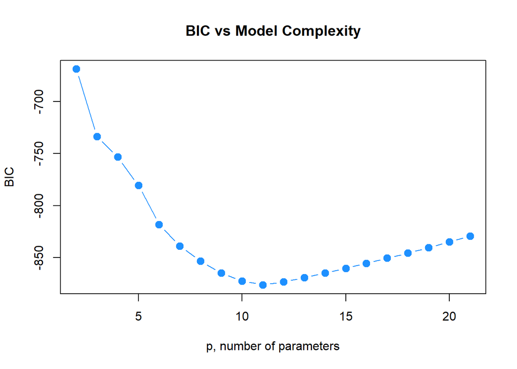

```r
plot(exh_bic ~ I(2:p), ylab = "BIC", xlab = "p, number of parameters",
     pch = 20, col = "dodgerblue", type = "b", cex = 2,
     main = "BIC vs Model Complexity")
```

The plot above shows the **BIC** of models with different number of parameters found by `regsubsets`

```r
which.min(exh_bic)
```

```
## [1] 10
```

```r
all_mod$which[which.min(exh_bic),][all_mod$which[which.min(exh_bic),]]
```

```
## (Intercept)      PCDH12        DLG5      SHISA5    AF161342       CARKD
##        TRUE        TRUE        TRUE        TRUE        TRUE        TRUE
##         F2R       PHKG1     PLEKHM1        PPAN   C14orf143
##        TRUE        TRUE        TRUE        TRUE        TRUE
```

The model found by **exhausitive search** has the same response and predictors as the model found by **backward search**. Therefore, the two different methods lead to exactly the same model.

### Conclusion

The best proper model found in the project is the one uses $Disease.Severity^{-0.25} - 1 \over -0.25$ as response and `PCDH12`,`DLG5`,`SHISA5`,`AF161342`,`CARKD`,`F2R`,`PHKG1`,`PLEKHM1`,`PPAN`,`C14orf143` as predictors. The model has a $R^2$ value `0.6922`.

For further improvement, I would suggest to add interaction or polynomial terms in the predicors. The more terms in the predictors will improve the accuracy of prediction, but as a tradeoff, this will make the model complex and hard to interpret. The choice of variables should be based on the need of the model.